# Open science

PCB 6455 / BSC 4933: Biometry | Lecture 29

Dr. Brian Maitner

## Today’s agenda

1. Final presentation reminder
2. Code and data sharing
3. Coding time in class (optional)

## Last call: course evaluations

**The online course evaluation closes tomorrow,** Friday, December 4. The link is in your USF email and on Canvas.

**If you haven’t done it yet, today is a good day.** Your comments shape how this course runs next year.

## The story so far

**Lecture 27:** what to do when code breaks, and asking for help with a reprex.

**Lecture 28:** making a whole project run on someone else’s computer.

**Today:** why share your data, code and methods at all, and how.

## Final presentations

**During the scheduled final exam block** (December 5 to 10). The day and time are on Canvas.

**Add your slides to the shared Google Slides file beforehand.**

**Practice your timing** to make sure you’re under 5 minutes.

## Your turn: would you share it?

**Your final project: would you share its data and code publicly?**

**If not, what would stop you?**

# Open science

## What is Open Science?

Open Science: “transparent and accessible knowledge that is shared and developed through collaborative networks”

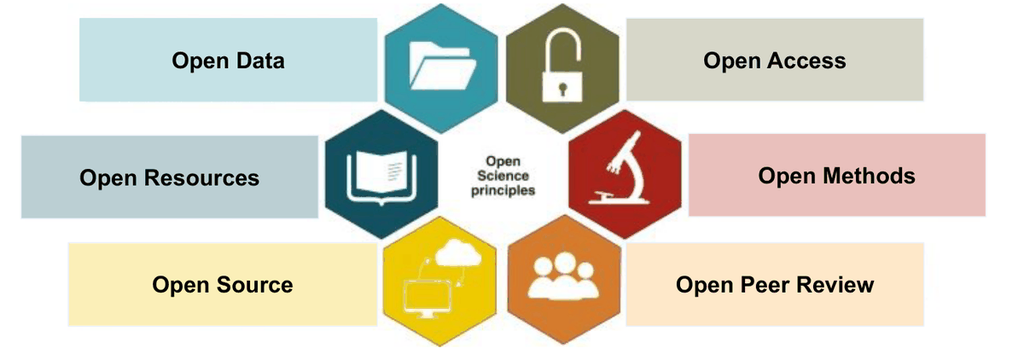

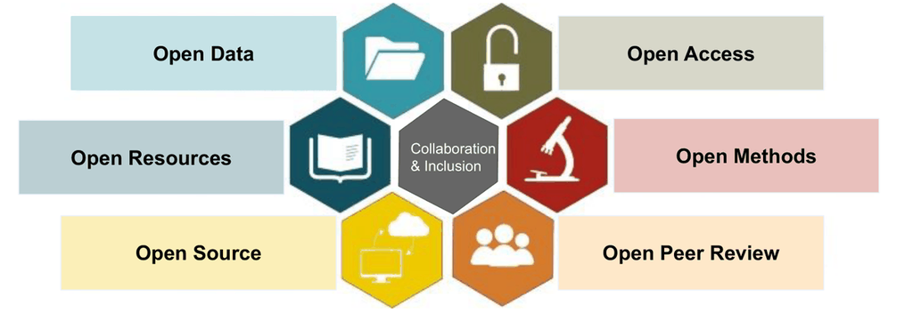

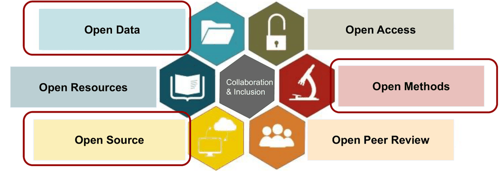

Gallagher et al. (2020) *Nature Ecology & Evolution*

# Open data

## What are open data?

**Available and accessible:** the data must be *available as a whole* and at no more than a reasonable reproduction cost, preferably by downloading over the internet. The data must also be available in a *convenient and modifiable form*.

**Reusable and redistributable:** the data must be provided under terms that *permit re-use and redistribution*, including the intermixing with other datasets.

**Universal participation:** *everyone must be able to use*, re-use and redistribute. There should be no discrimination against fields of endeavor or against persons or groups.

opendatahandbook.org

## Your turn: is it open?

Pick one of these folders in the course repository’s `data/`, and read its README: `Avonet`, `Mangroves`, `Reef_fish` or `Beetle_competition`.

**Where are the data archived? Under what license? Could you reuse them in a published paper?**

| Dataset | Archived | License | Open? |
| --- | --- | --- | --- |
| Avonet | figshare | CC BY 4.0 | yes |
| Reef_fish | NOAA, with a DOI | CC0 | yes |
| Mangroves | a university repository, with a DOI | CC BY-NC 4.0 | not by this definition: no commercial use |
| Beetle_competition | only on GitHub | CC BY 4.0 | open, but not archived: one copy, no DOI |

## Global questions need global participation

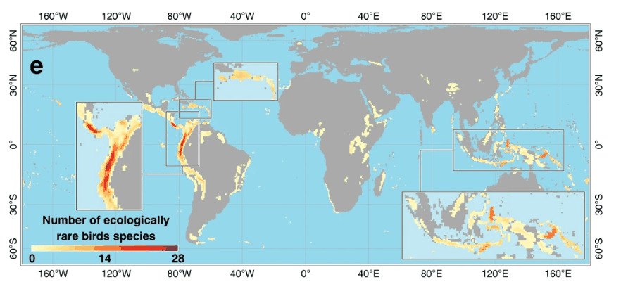

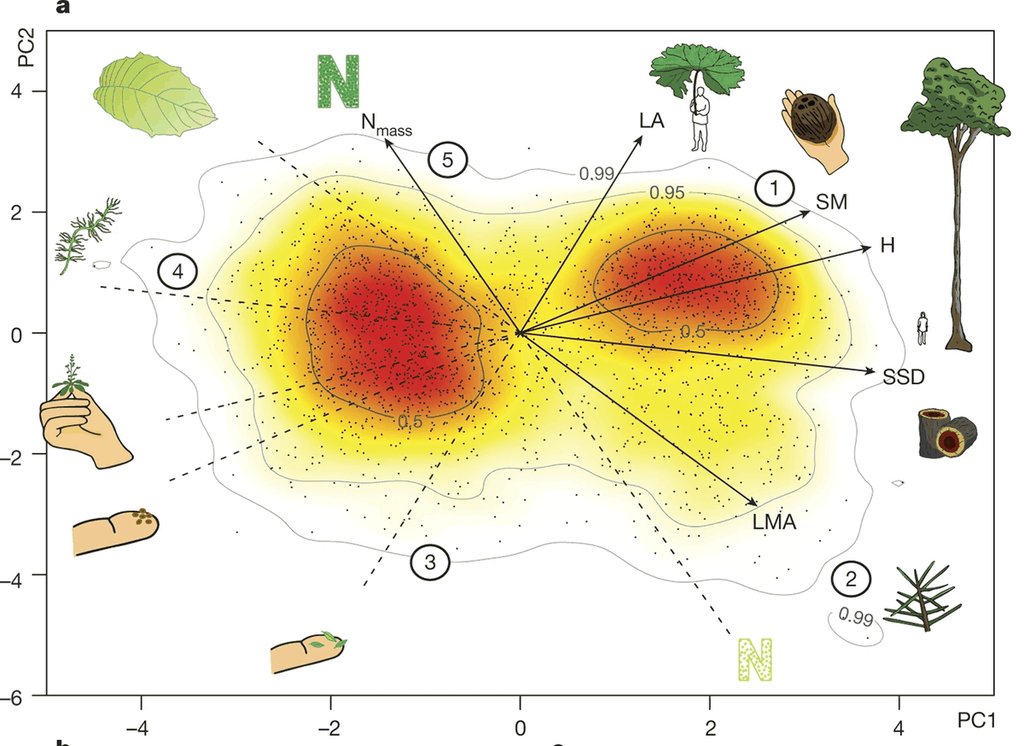

Global spectrum of plant form and function

Loiseau et al. (2020) *Nature Communications*; Díaz et al. (2016) *Nature*

## Open data enhance reproducibility

[figure not shown]

Baker (2016) *Nature*

## Ethical responsibilities

**Publicly funded data are public property.**

**Transparency is a key part of science.**

**Open data increase inclusion.**

**Open data save money!**

Piwowar et al. (2011) *Nature*

## Open data improve citations and publications

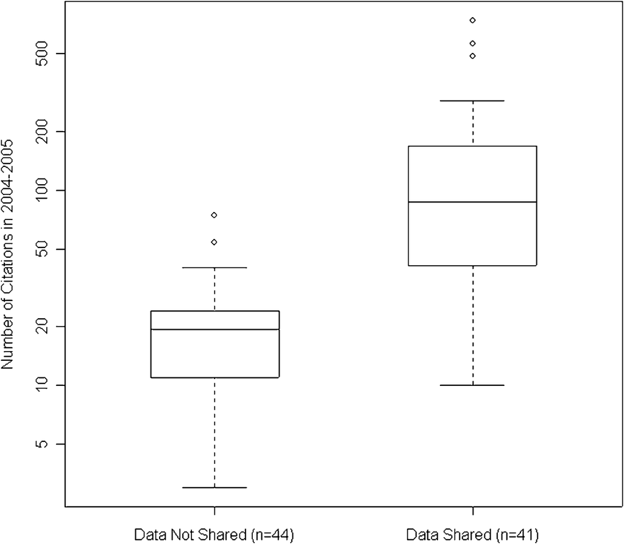

[figure not shown]

Piwowar et al. (2007) *PLOS ONE*

## How to share data

**Range of options**

[figure not shown]

[figure not shown]

[figure not shown]

[figure not shown]

[figure not shown]

**Best option:** **L**ots **O**f **C**opies **K**eep **S**tuff **S**afe (**LOCKSS**)

Less risk of loss, and more chance people find it (and cite it).

Keller et al. (2022) *Methods in Ecology and Evolution*

## What is Open Science?

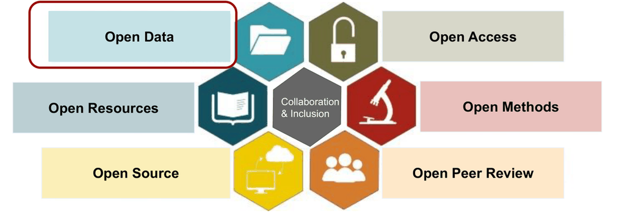

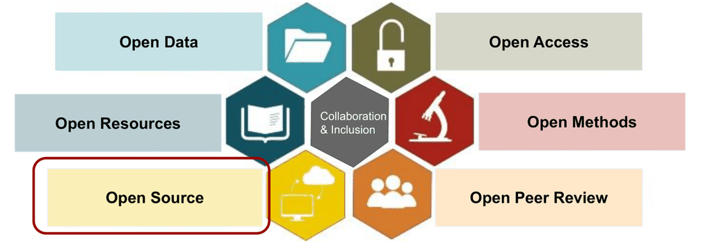

Gallagher et al. (2020) *Nature Ecology & Evolution*

# Open source

## What is open source?

**Free redistribution:** the license shall not restrict any party from selling or giving away the software as a component of an aggregate software distribution containing programs from several different sources. The license *shall not require a royalty or other fee* for such sale.

**No discrimination against persons or groups:** the license must not discriminate against any person or group of persons.

**No discrimination against fields of endeavor:** the license must not restrict anyone from making use of the program in a specific field of endeavor. For example, it may not restrict the program from being used in a business, or from being used for genetic research.

**In short: code that is free to use, both in terms of costs and restrictions.**

opensource.org/osd

## Your turn: which are open source?

R · RStudio Desktop · Python · QGIS · Excel · ArcGIS · MATLAB · JMP · Google Earth

| **Open source** | R, RStudio Desktop, Python, QGIS |
| --- | --- |
| **Paid and closed** | Excel, ArcGIS, MATLAB, JMP |
| **Free, but not open source** | Google Earth |

Free to use is not the same as open: with closed software you can’t read, change or redistribute the code.

## Reproducibility and transparency

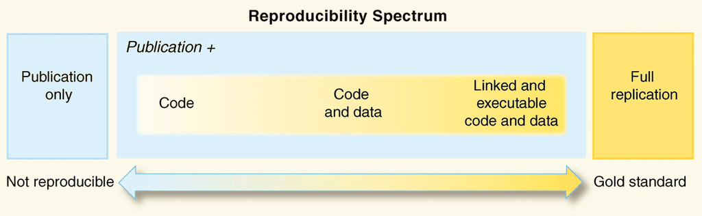

Peng (2011) *Science*

## Open source reduces wasted efforts

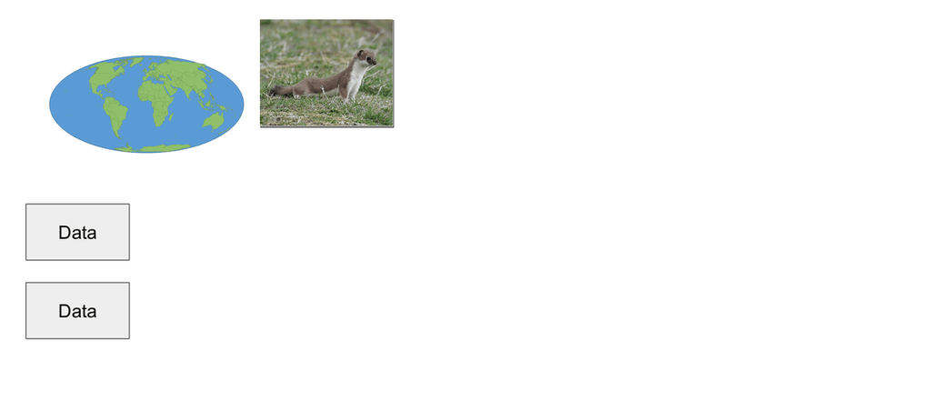

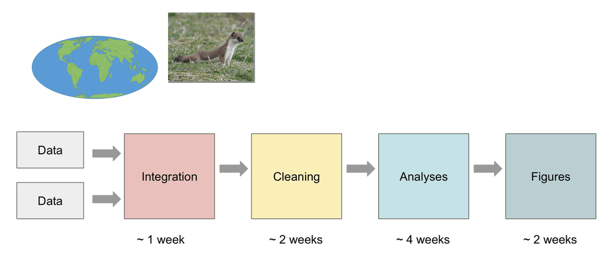

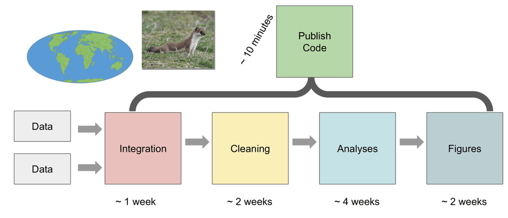

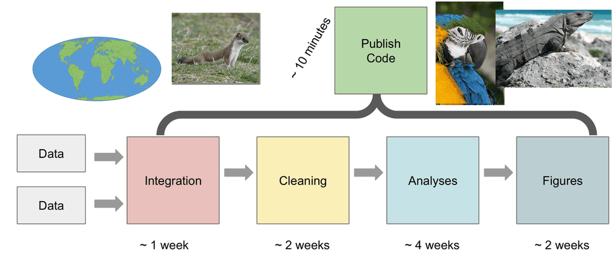

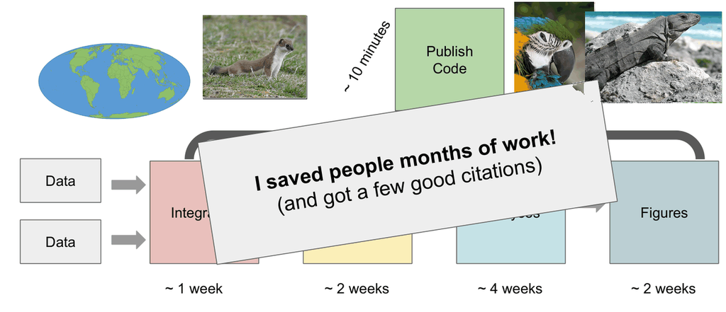

Photos via Wikimedia Commons: stoat, Justin Philbois (CC0); macaw, Jebulon (CC0); black spiny-tailed iguana, Ken Thomas (public domain).

## Open source reduces barriers

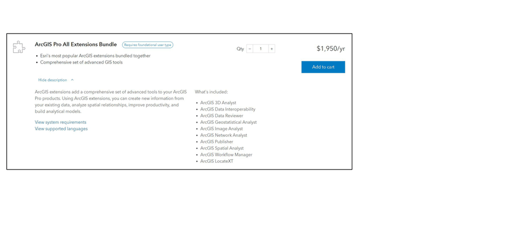

[figure not shown]

[figure not shown]

[figure not shown]

## Code sharing increases citations

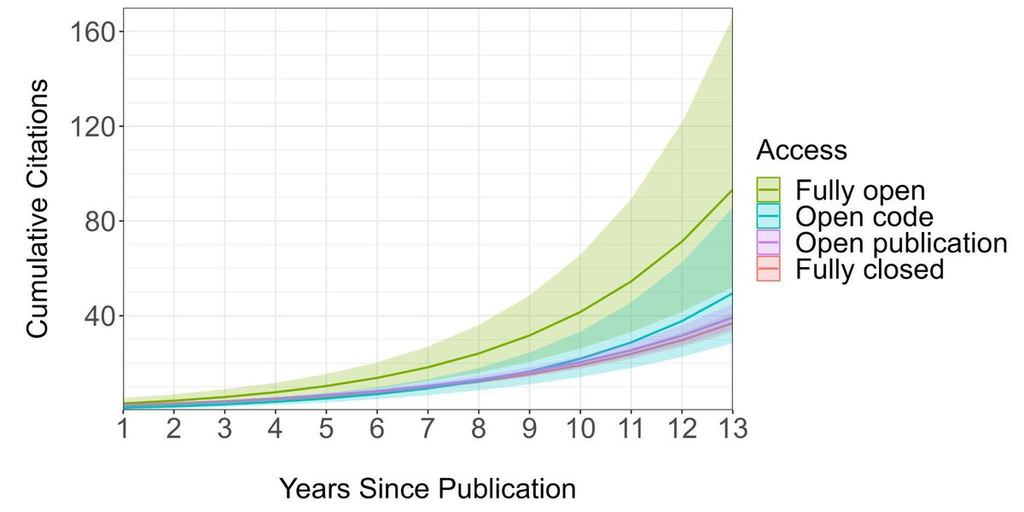

Maitner et al. (2024) *Ecology and Evolution*

## What is Open Science?

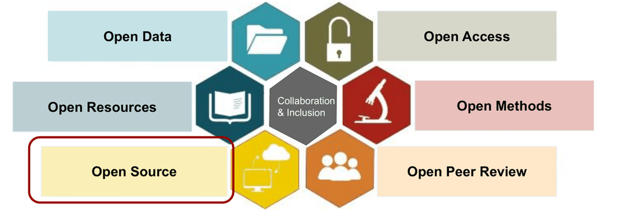

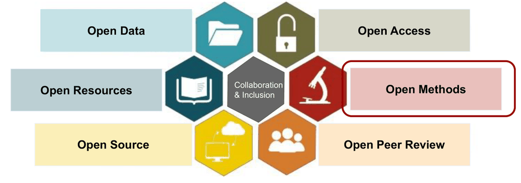

Gallagher et al. (2020) *Nature Ecology & Evolution*

# Open methods

## What are open methods?

Making the methods underlying research open and freely accessible.

**Examples:** laboratory protocols, data collection protocols, metadata standards, materials, reagents, and code (which overlaps with open source).

## Open methods increase transparency

[figure not shown]

Baker (2016) *Nature*

## Shared methods increase confidence

[figure not shown]

[figure not shown]

Pérez-Harguindeguy et al. (2013) *Australian Journal of Botany*; Halbritter et al. (2020) *Methods in Ecology and Evolution*

## Shared methods increase compatibility

**Data integration is a major time sink.**

**Using shared metadata standards and methods** increases interoperability.

[figure not shown]

Schneider et al. (2019) *Methods in Ecology and Evolution*